# Iris Flower Classification

## Objective

The objective of this project is to build a machine learning model that classifies Iris flowers into Setosa, Versicolor, and Virginica based on their physical measurements.

```python
import pandas as pd
import numpy as np
import matplotlib.pyplot as plt
import seaborn as sns

from sklearn.datasets import load_iris
from sklearn.model_selection import train_test_split

from sklearn.linear_model import LogisticRegression
from sklearn.neighbors import KNeighborsClassifier

from sklearn.metrics import accuracy_score, confusion_matrix, classification_report
```

```python
iris = load_iris()

df = pd.DataFrame(iris.data, columns=iris.feature_names)

df["species"] = iris.target
df["species"] = df["species"].map({
    0: "setosa",
    1: "versicolor",
    2: "virginica"
})
```

```python
df.head()
```

|  | sepal length (cm) | sepal width (cm) | petal length (cm) | petal width (cm) | species |
| --- | --- | --- | --- | --- | --- |
| 0 | 5.1 | 3.5 | 1.4 | 0.2 | setosa |
| 1 | 4.9 | 3.0 | 1.4 | 0.2 | setosa |
| 2 | 4.7 | 3.2 | 1.3 | 0.2 | setosa |
| 3 | 4.6 | 3.1 | 1.5 | 0.2 | setosa |
| 4 | 5.0 | 3.6 | 1.4 | 0.2 | setosa |

## Exploratory Data Analysis (EDA)

```python
print("Shape:", df.shape)
```

```
Shape: (150, 5)
```

```python
print("\nColumns:")
print(df.columns)
```

```
Columns:
Index(['sepal length (cm)', 'sepal width (cm)', 'petal length (cm)',
       'petal width (cm)', 'species'],
      dtype='object')
```

```python
print("\nData Types:")
print(df.dtypes)
```

```
Data Types:
sepal length (cm)    float64
sepal width (cm)     float64
petal length (cm)    float64
petal width (cm)     float64
species               object
dtype: object
```

```python
print("\nMissing Values:")
print(df.isnull().sum())
```

```
Missing Values:
sepal length (cm)    0
sepal width (cm)     0
petal length (cm)    0
petal width (cm)     0
species              0
dtype: int64
```

```python
print("\nStatistical Summary:")
print(df.describe())
```

```
Statistical Summary:
       sepal length (cm)  sepal width (cm)  petal length (cm)  \
count         150.000000        150.000000         150.000000
mean            5.843333          3.057333           3.758000
std             0.828066          0.435866           1.765298
min             4.300000          2.000000           1.000000
25%             5.100000          2.800000           1.600000
50%             5.800000          3.000000           4.350000
75%             6.400000          3.300000           5.100000
max             7.900000          4.400000           6.900000

       petal width (cm)
count        150.000000
mean           1.199333
std            0.762238
min            0.100000
25%            0.300000
50%            1.300000
75%            1.800000
max            2.500000
```

## Pairplot

The pairplot shows the relationship between different features of the Iris dataset. Different colors represent different flower species.

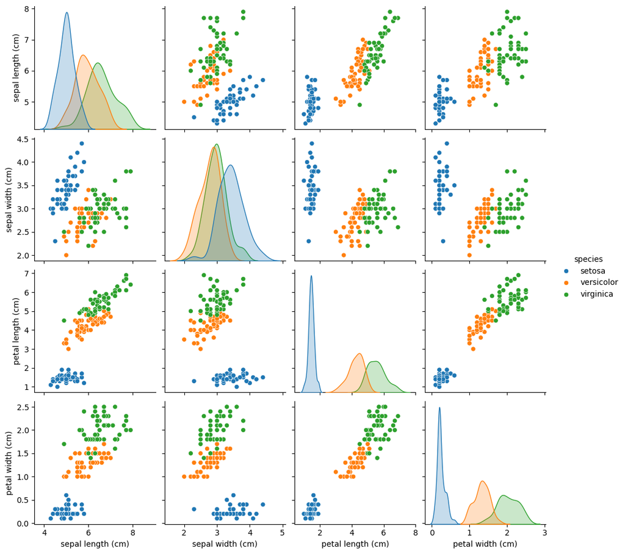

```python
# Pairplot
sns.pairplot(df, hue="species")
plt.show()
```

## Boxplots

Boxplots help identify the distribution of each feature and detect possible outliers.

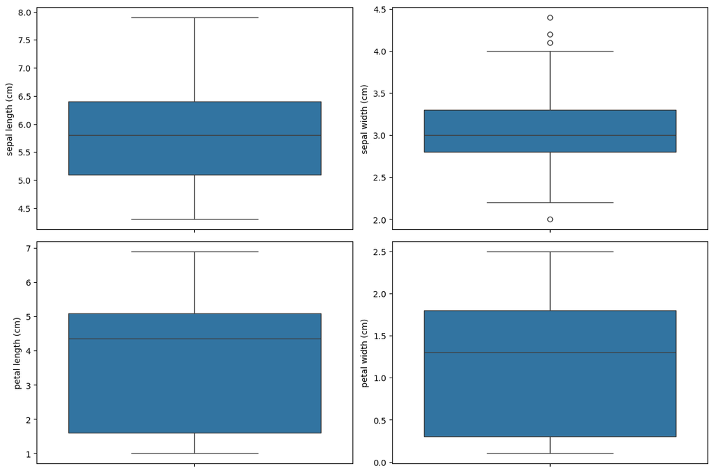

```python
plt.figure(figsize=(12,8))

plt.subplot(2,2,1)
sns.boxplot(y=df["sepal length (cm)"])

plt.subplot(2,2,2)
sns.boxplot(y=df["sepal width (cm)"])

plt.subplot(2,2,3)
sns.boxplot(y=df["petal length (cm)"])

plt.subplot(2,2,4)
sns.boxplot(y=df["petal width (cm)"])

plt.tight_layout()
plt.show()
```

## Feature Selection

Among all the features, petal length and petal width are the most discriminative because they clearly separate the three Iris species. Sepal length and sepal width also contribute to classification but have more overlap between species.

## Train-Test Split

The dataset is divided into training (80%) and testing (20%) sets. The training data is used to build the model, while the testing data is used to evaluate its performance.

```python
X = df.drop("species", axis=1)
y = df["species"]

X_train, X_test, y_train, y_test = train_test_split(
    X, y,
    test_size=0.2,
    random_state=42
)

print("Training data shape:", X_train.shape)
print("Testing data shape:", X_test.shape)
```

```
Training data shape: (120, 4)
Testing data shape: (30, 4)
```

## Logistic Regression Model

```python
lr = LogisticRegression(max_iter=200)

lr.fit(X_train, y_train)

y_pred_lr = lr.predict(X_test)

print("Logistic Regression Accuracy:", accuracy_score(y_test, y_pred_lr))
```

```
Logistic Regression Accuracy: 1.0
```

## K-Nearest Neighbors (KNN) Model

```python
knn = KNeighborsClassifier(n_neighbors=3)

knn.fit(X_train, y_train)

y_pred_knn = knn.predict(X_test)

print("KNN Accuracy:", accuracy_score(y_test, y_pred_knn))
```

```
KNN Accuracy: 1.0
```

## Model Evaluation

```python
print("Logistic Regression Confusion Matrix")
print(confusion_matrix(y_test, y_pred_lr))

print("\nClassification Report")
print(classification_report(y_test, y_pred_lr))
```

```
Logistic Regression Confusion Matrix
[[10  0  0]
 [ 0  9  0]
 [ 0  0 11]]

Classification Report
              precision    recall  f1-score   support

      setosa       1.00      1.00      1.00        10
  versicolor       1.00      1.00      1.00         9
   virginica       1.00      1.00      1.00        11

    accuracy                           1.00        30
   macro avg       1.00      1.00      1.00        30
weighted avg       1.00      1.00      1.00        30
```

```python
print("KNN Confusion Matrix")
print(confusion_matrix(y_test, y_pred_knn))

print("\nClassification Report")
print(classification_report(y_test, y_pred_knn))
```

```
KNN Confusion Matrix
[[10  0  0]
 [ 0  9  0]
 [ 0  0 11]]

Classification Report
              precision    recall  f1-score   support

      setosa       1.00      1.00      1.00        10
  versicolor       1.00      1.00      1.00         9
   virginica       1.00      1.00      1.00        11

    accuracy                           1.00        30
   macro avg       1.00      1.00      1.00        30
weighted avg       1.00      1.00      1.00        30
```

# Conclusion